# F01-Generating Figures for the Comparative Study

Jake Reed

2025-01-21

# Data

# Analysis workflow

1. Load the data
2. Organize the data
3. Table 1: Data Sets
4. Plot 1: Sensitivity
5. Plot 2: Accuracy
6. Plot 3: Compare Lengths
7. Plot 4: Benchmarks
8. Plot 5: ?

## Somewhere in here we need to compare workflows in the introduction.

# Purpose

The purpose of this analysis is to compare the results of the TECAT and Telogator tools to the Telseq tool.

# Introduction to the analysis

The data used in this analysis is the results of comparing the telomere end-chromosome length assaying tools TECAT and Telogator, along with the short read analysis tool Telseq. Telomere lengths are important in determining FCR treatment response in CLL patients and have been shown to be a prognostic marker in CLL and other cancers. Telomere’s are also implicated in aging and neurodegenerative diseases. Normal telomere length varies from 1kb to 15kb depending on age. As of now there are two software packages which measure telomere length at the resolution of individual chromosomes: TECAT and Telogator. Telseq is a short read analysis tool that can be used to measure telomere length. The purpose of including Telseq in this analysis is to provide some type of ground truth for the other two tools.

# Setup

```r
knitr::opts_chunk$set(echo = TRUE)
knitr::opts_knit$set(root.dir = "/home/jake/science_projects/telo/comparative_study")
```

# Libraries

```r
library(tidyverse)
library(plyr)
library(knitr)
library(kableExtra)
```

```r
library(ggplot2)
library(ggpubr)
library(gridExtra)
library(cowplot)
library(reshape2)
```

# Samples

```r
# Create the data frame, including ineligible rows with a note
data <- data.frame(
  Number = c(1, 2, 3, 4, 5, 6, 7, 8, 9, "-10", "-11", "-12", 10, 11, 12),
  SampleID = c("HG002", "HG003", "HG004", "HG00731", "HG00732", "HG02011",
               "HG02492", "HG03065", "HG03371", "HG03683", "NA12329",
               "NA19983", "HG00514", "HG00733", "NA19240"),
  `Long Read Accession` = c("SRR28295757-71", "SRR12898316", "SRR27010837",
                          "ERR11586165", "ERR4987503-05", "ERR11028132",
                          "ERR11028099", "ERR11028096", "ERR11028137",
                          "ERR3861403", "ERR3861409-10", "ERR3861402",
                          "ERR4982327", "SRR24401966", "ERR3219853-57"),
  Short_Read_Accession = c("SRR14724532", "SRR14724530", "SRR14724529",
                           "ERR10967205", "ERR3241755", "ERR3988973",
                           "ERR3989019", "ERR3989118", "ERR3989162",
                           "ERR3989199", "ERR3989317", "ERR3989454",
                           "ERR3988781", "SRR5535410-11", "ERR3989410"),
  Type = c("ONT", "ONT", "ONT", "ONT", "PB", "ONT", "ONT", "ONT",
              "ONT", "PB", "PB", "PB", "PB", "ONT", "ONT"),
  Notes = c("", "", "", "updated SR SRR5534404-5", "", "", "", "", "",
            "CLR - not eligible", "CLR - not eligible", "CLR - not eligible", "", "", "")
)

# Remove the samples where the sample number has a negative sign
data <- data[!grepl("-", data$Number), ]
data <- data[, 1:5]
df <- data

# Current samples list
samples <- c("HG002", "HG004", "HG00731", "HG00732", "HG02011", "HG02492", "HG03065", "HG03371", "HG00514")
```

# Publication ready table

```r
sample_table <- kable(df,
       format = "html",
       col.names = c("Sample Number", "Sample ID", "Long Read Accession", "Short Read Accession", "Type"),
       row.names = FALSE,
       align = c("c", "c", "c", "c", "c"),
       caption = "<font style='font-size:16pt'><b>Table 1</b> Sample Data</font>") %>%
 kable_classic(full_width = FALSE, html_font = "Arial", font_size = 14)
# kableExtra::save_kable(sample_table, file = "./results/paper_figures/sample_table.png", density = 600, zoom = 1.5)

sample_table
```

**Table 1** Sample Data

| Sample Number | Sample ID | Long Read Accession | Short Read Accession | Type |
| --- | --- | --- | --- | --- |
| 1 | HG002 | SRR28295757-71 | SRR14724532 | ONT |
| 2 | HG003 | SRR12898316 | SRR14724530 | ONT |
| 3 | HG004 | SRR27010837 | SRR14724529 | ONT |
| 4 | HG00731 | ERR11586165 | ERR10967205 | ONT |
| 5 | HG00732 | ERR4987503-05 | ERR3241755 | PB |
| 6 | HG02011 | ERR11028132 | ERR3988973 | ONT |
| 7 | HG02492 | ERR11028099 | ERR3989019 | ONT |
| 8 | HG03065 | ERR11028096 | ERR3989118 | ONT |
| 9 | HG03371 | ERR11028137 | ERR3989162 | ONT |
| 10 | HG00514 | ERR4982327 | ERR3988781 | PB |
| 11 | HG00733 | SRR24401966 | SRR5535410-11 | ONT |
| 12 | NA19240 | ERR3219853-57 | ERR3989410 | ONT |

# Sensitivity

```r
# Retrieve the data
tecat_reads <- list()
telogator_reads <- list()

for(s in samples) {
    tecat_reads[[s]] <- as.numeric(strsplit(grep("Number of telomeres", readLines(file.path("./code/logs", paste0(s, ".log"))), value = TRUE), ":")[[1]][2])
    telogator_grep <- "^ -"
    line <- grep(telogator_grep, readLines(file.path("./code/logs", paste0(s, ".log"))), value = TRUE)[[3]]
    telogator_reads[[s]] <- as.numeric(gsub("reads", "", strsplit(line, "-->")[[1]][2]) )
}

raw <- data.frame()
for(s in samples) {
    raw <- rbind(raw, data.frame(Sample = s, TECAT = tecat_reads[[s]], Telogator = telogator_reads[[s]]))
}

head(raw)
```

```
##    Sample TECAT Telogator
## 1   HG002  1880      2516
## 2   HG004   248       436
## 3 HG00731   638       817
## 4 HG00732   680       698
## 5 HG02011   826      1034
## 6 HG02492   671       844
```

## Plotting sensitivity

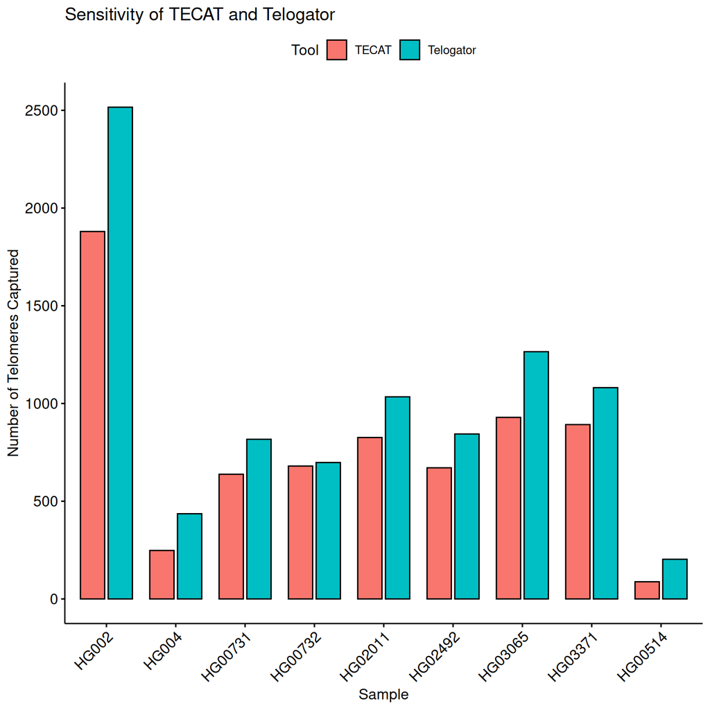

```r
sens <- raw %>%
  gather(key = "Tool", value = "Number of Telomeres Captured", -Sample) %>%
  ggbarplot(x = "Sample", y = "Number of Telomeres Captured", fill = "Tool",
            position = position_dodge(0.8),
            title = "Sensitivity of TECAT and Telogator",
            xlab = "Sample",
            ylab = "Number of Telomeres Captured",
            legend.title = "Tool",
            legend.position = "top",
            theme.legend.position = "top",
            theme = theme_pubr(),
            show.values = TRUE) +
            rotate_x_text(45)

sens
```

```r
perc <- raw$Telogator / raw$TECAT

perc
```

```
## [1] 1.338298 1.758065 1.280564 1.026471 1.251816 1.257824 1.361679 1.211883
## [9] 2.306818
```

```r
mean(c(0.33, 0.76, 0.28, .02, .25, .25, .36, .21, 1.30))
```

```
## [1] 0.4177778
```

```r
# Save plot
#ggsave(file = "./results/paper_figures/sensitivity_plot.png", plot = sens, width = 8, height = 6)
```

# Accuracy

```r
# Retrieve the data
tecat <- list()
telogator <- list()
telseq <- list()
for(s in samples) {
  tecat[[s]] <- readRDS(file = file.path("results", paste0(s), "tecat", "mapped.rds"))
  telogator[[s]] <- read.table(file = file.path("results", paste0(s), "telogator", "tlens_by_allele.tsv"), header = TRUE, sep = "\t", comment.char = "")
  telseq[[s]] <- readLines(file.path("results", paste0(s), "telseq", "telseq_results.txt"))
}

head(tecat$HG002$results)
```

```
##               telo_name ref_name strand start   end qwidth score
## 1  split_014_telomere_2    chr10      +  3157 17222  14066    10
## 2  split_080_telomere_7    chr10      +  3157 41029  37873     4
## 3  split_131_telomere_5    chr10      -  3162 29229  26068     6
## 4 split_016_telomere_10    chr10      -  3180  4747   1568    43
## 5 split_130_telomere_10    chr10      -  3181 39648  36468     4
## 6 split_023_telomere_10    chr10      -  3187 25768  22582     1
##   telomere_length read_length trunc_start trunc_end telomere_end chromEnd
## 1            7733       21799        7734     21799            L       5'
## 2            6233       44106        6234     44106            L       5'
## 3            7851       33919           1     26068            R       5'
## 4            4502        6070           1      1568            R       5'
## 5            6370       42838           1     36468            R       5'
## 6            4719       27301           1     22582            R       5'
##   sample
## 1  HG002
## 2  HG002
## 3  HG002
## 4  HG002
## 5  HG002
## 6  HG002
```

```r
dim(telogator$HG002)
```

```
## [1] 92 11
```

```r
dim(tecat$HG002$results)
```

```
## [1] 1765   14
```

```r
names(telogator$HG002)
```

```
##  [1] "X.chr"            "position"         "ref_samp"         "allele_id"
##  [5] "TL_p75"           "read_TLs"         "read_lengths"     "read_mapq"
##  [9] "tvr_len"          "tvr_consensus"    "supporting_reads"
```

```r
telogator$HG002[1:5,1:6]
```

```
##   X.chr position      ref_samp allele_id TL_p75
## 1 chr1p     3311 t2t-hg002-mat     47+0i   2238
## 2 chr1p     4321 t2t-hg002-pat     86+0i   8667
## 3 chr1q   495845 t2t-hg002-mat     41+0i   4684
## 4 chr1q   495897 t2t-hg002-pat     77+0i   5540
## 5 chr2p     2974 t2t-hg002-pat     19+0i   4506
##                                                                                                    read_TLs
## 1           1078,1345,1483,1503,1555,1570,1574,1654,1672,1698,1716,1788,2111,2183,2294,2467,2614,2647,10493
## 2                                                279,3709,6650,7945,7947,7978,8102,8444,8623,8801,8952,8991
## 3 -2031,-613,3388,3630,3686,3947,4022,4295,4322,4402,4405,4500,4519,4527,4640,4684,4805,4839,4945,8355,9483
## 4                          2899,3079,3335,3559,3795,4443,4541,4762,4957,5129,5267,5360,6082,6611,8345,12261
## 5                                     3678,3788,3802,3828,3837,3864,4277,4339,4441,4453,4524,4557,5051,6850
```

## Collect telomere lengths

```r
tecat_lengths <- list()
telogator_lengths <- list()
telseq_length <- list()
for(s in samples) {
    tecat_lengths[[s]] <- tecat[[s]]$results %>%
        filter(!is.na(telomere_length)) %>%
        pull(telomere_length)
    telogator_lengths[[s]] <- as.numeric(unlist(strsplit(telogator[[s]]$read_TLs, ",")))
    telseq_length[[s]] <- as.numeric(unlist(strsplit(telseq[[s]][4], "\t"))[7])
}
```

## Basic plots of data

[figure not shown]

[figure not shown]

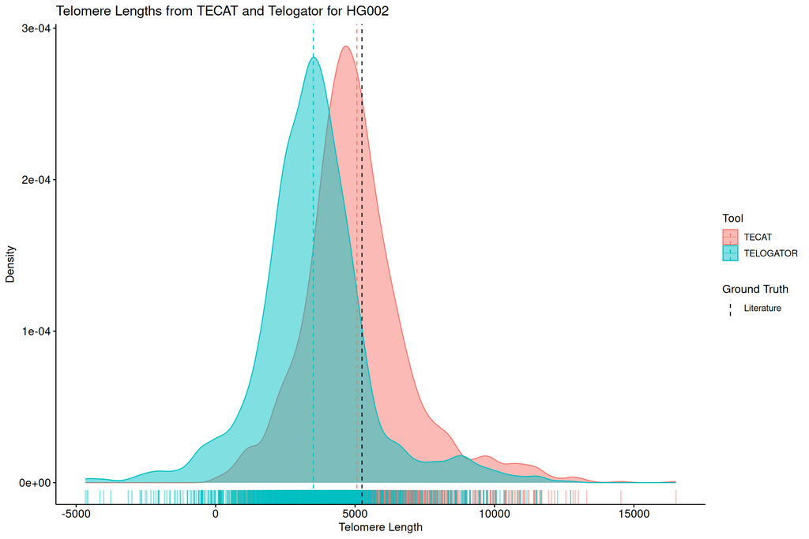

```r
histo_data <- list()
for(s in samples) {
    histo_data[[s]] <- data.frame(
        length = c(tecat_lengths[[s]], telogator_lengths[[s]]),
        Tool = c(rep("TECAT", length(tecat_lengths[[s]])), rep("TELOGATOR", length(telogator_lengths[[s]])))
    )
}

# Initially just HG002
hg002 <- histo_data[["HG002"]]
line <- c(5247)
dens <- ggdensity(data = hg002, x = "length", fill = "Tool",
          add = "mean",
          color = "Tool",
          rug = TRUE,
          title = "Telomere Lengths from TECAT and Telogator for HG002",
          xlab = "Telomere Length",
          ylab = "Density",
          legend.title = "Tool",
          legend.position = "top",
          theme = theme_pubr())
dens <- dens + geom_vline(aes(xintercept = line, linetype = "Literature")) +
  scale_fill_manual(name = "Tool",
                    values = c("TECAT" = "#F8766D", "TELOGATOR" = "#00BFC4")) +
  scale_linetype_manual(name = "Ground Truth",
                        values = c("Literature" = "dashed")) +
  theme(legend.position = "right")

dens
```

```r
# Save plot
#ggsave(file = "./results/paper_figures/density_plot.png", plot = dens, width = 12, height = 6)
```

# Descriptive statistics of each sample

```r
# Create a data frame with the mean, median, and standard deviation of each sample
descriptive <- data.frame(
  Sample = samples,
  TECAT_Mean = sapply(tecat_lengths, mean),
  TECAT_Median = sapply(tecat_lengths, median),
  TECAT_SD = sapply(tecat_lengths, sd),
  TELOGATOR_Mean = sapply(telogator_lengths, mean),
  TELOGATOR_Median = sapply(telogator_lengths, median),
  TELOGATOR_SD = sapply(telogator_lengths, sd),
  TELSEQ_Mean = sapply(telseq_length, mean),
  TELSEQ_Median = sapply(telseq_length, median),
  TELSEQ_SD = sapply(telseq_length, sd)
)

# Create a table with the descriptive statistics
descriptive_table <- kable(descriptive,
                            format = "html",
                            col.names = c("Sample", "TECAT Mean", "TECAT Median", "TECAT SD",
                                          "TELOGATOR Mean", "TELOGATOR Median", "TELOGATOR SD",
                                          "TELSEQ Mean", "TELSEQ Median", "TELSEQ SD"),
                            row.names = FALSE,
                            align = c("c", "c", "c", "c", "c", "c", "c", "c", "c", "c"),
                            caption = "<font style='font-size:16pt'><b>Table 2</b> Descriptive Statistics of Telomere Lengths</font>") %>%
  kable_classic(full_width = FALSE, html_font = "Arial", font_size = 14)

descriptive_table
```

**Table 2** Descriptive Statistics of Telomere Lengths

| Sample | TECAT Mean | TECAT Median | TECAT SD | TELOGATOR Mean | TELOGATOR Median | TELOGATOR SD | TELSEQ Mean | TELSEQ Median | TELSEQ SD |
| --- | --- | --- | --- | --- | --- | --- | --- | --- | --- |
| HG002 | 5066.779 | 4840.0 | 1936.769 | 3502.715 | 3440.0 | 2049.940 | 4.304960 | 4.304960 | NA |
| HG004 | 1177.311 | 588.0 | 1399.323 | 3596.677 | 3676.5 | 2418.483 | 0.943523 | 0.943523 | NA |
| HG00731 | 8628.705 | 8212.0 | 5574.278 | 5038.966 | 4939.0 | 6312.307 | 13.766400 | 13.766400 | NA |
| HG00732 | 2907.744 | 2714.0 | 1702.076 | 1528.447 | 1203.0 | 1531.135 | 5.634480 | 5.634480 | NA |
| HG02011 | 7166.993 | 7198.5 | 4103.128 | 3289.303 | 3242.0 | 5001.186 | 7.136420 | 7.136420 | NA |
| HG02492 | 7160.498 | 6224.5 | 4489.298 | 3049.590 | 3584.5 | 4992.413 | 7.668080 | 7.668080 | NA |
| HG03065 | 3572.709 | 3445.5 | 1877.793 | 1883.230 | 1738.5 | 2083.927 | 3.967210 | 3.967210 | NA |
| HG03371 | 8796.542 | 10123.0 | 5189.908 | 8314.436 | 8908.0 | 4971.891 | 11.185100 | 11.185100 | NA |
| HG00514 | 4803.987 | 5324.5 | 2298.209 | 3841.528 | 4331.0 | 2242.501 | 9.111000 | 9.111000 | NA |

```r
# May include this in the publication, need to work it out
```

## Boxplot of telomere lengths

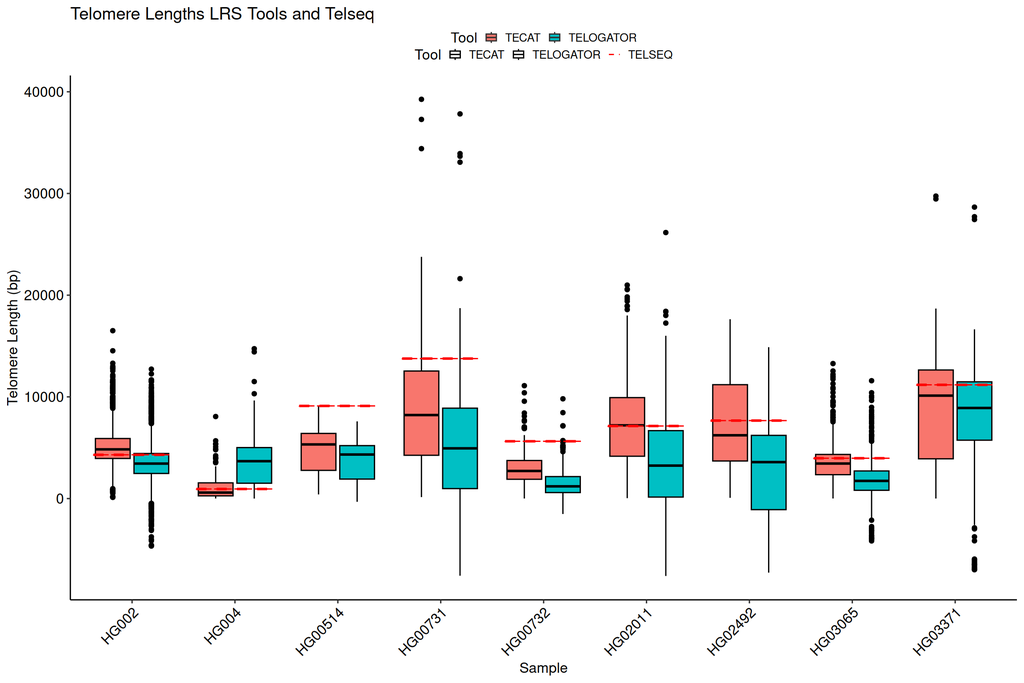

```r
# Combine histo datas for both samples with sample labels
boxplot <- rbind(
    cbind(histo_data[["HG002"]], sample = "HG002"),
    cbind(histo_data[["HG004"]], sample = "HG004"),
    cbind(histo_data[["HG00731"]], sample = "HG00731"),
    cbind(histo_data[["HG00732"]], sample = "HG00732"),
    cbind(histo_data[["HG02011"]], sample = "HG02011"),
    cbind(histo_data[["HG02492"]], sample = "HG02492"),
    cbind(histo_data[["HG03065"]], sample = "HG03065"),
    cbind(histo_data[["HG03371"]], sample = "HG03371"),
    cbind(histo_data[["HG00514"]], sample = "HG00514")
)

# Add telseq data to boxplot
boxplot <- rbind(
    boxplot,
    data.frame(
        length = unlist(telseq_length) * 1000,
        Tool = rep("TELSEQ", length(unlist(telseq_length))),
        sample = rep(samples, each = 1)
    )
)

boxplot$Tool <- factor(boxplot$Tool, levels = c("TECAT", "TELSEQ", "TELOGATOR"))

box <- ggplot() +
  # Layer for TECAT and TELOGATOR with boxplots
  geom_boxplot(data = subset(boxplot, Tool != "TELSEQ"),
               aes(x = sample, y = length, fill = Tool, color = Tool, linetype = Tool)) +
  # Layer for TELSEQ with just a line in legend
  geom_boxplot(data = subset(boxplot, Tool == "TELSEQ"),
               aes(x = sample, y = length, color = Tool, linetype = Tool),
               show.legend = TRUE,
               key_glyph = "path") +
  scale_fill_manual(values = c("#F8766D", "#00BFC4", "red")) +
  scale_color_manual(values = c("black", "black", "red")) +
  scale_linetype_manual(values = c("solid", "solid", "dashed")) +
  labs(title = "Telomere Lengths LRS Tools and Telseq",
       x = "Sample",
       y = "Telomere Length (bp)",
       color = "Tool") +
  theme_pubr() +
  theme(legend.position = "top",
        legend.box = "vertical",
        legend.margin = margin(0, 0, 0, 0),  # Reduce margin around each legend
        legend.spacing = unit(0.1, "cm"),     # Reduce space between legends
        legend.key.size = unit(0.8, "lines"), # Make legend keys smaller
        axis.text.x = element_text(angle = 45, hjust = 1))

box
```

```r
# Perform t-tests for each sample
tecat_tests <- lapply(samples, function(s) {
  wilcox.test(boxplot[["length"]][boxplot[["Tool"]] == "TECAT" & boxplot[["sample"]] == s],
         mu = boxplot[["length"]][boxplot[["Tool"]] == "TELSEQ" & boxplot[["sample"]] == s])
})

telogator_tests <- lapply(samples, function(s) {
  wilcox.test(boxplot[["length"]][boxplot[["Tool"]] == "TELOGATOR" & boxplot[["sample"]] == s],
         mu = boxplot[["length"]][boxplot[["Tool"]] == "TELSEQ" & boxplot[["sample"]] == s])
})

# Extract p-values
tecat_pv <- sapply(tecat_tests, function(t) t$p.value)
telogator_pv <- sapply(telogator_tests, function(t) t$p.value)

# Create a data frame with the p-values
p_values_df <- data.frame(
  Sample = samples,
  TECAT = tecat_pv,
  TELOGATOR = telogator_pv
)

# First reshape p_values_df to long format for easier plotting
p_values_df <- tidyr::pivot_longer(p_values_df,
                                   cols = c("TECAT", "TELOGATOR"),
                                   names_to = "Method",
                                   values_to = "p_value")

pvalue_plot <- data.frame(
 Sample = samples,
 TECAT = -log10(tecat_pv),
 TELOGATOR = -log10(telogator_pv)
)

# Heatmap with just exponent values
pplot <- ggplot(pvalue_plot, aes(y=Sample)) +
 geom_tile(aes(x="TECAT", fill=TECAT)) +
 geom_tile(aes(x="TELOGATOR", fill=TELOGATOR)) +
 scale_fill_gradientn(
   colors = c("white", "#00FF00", "#000099"),
   name="p-value (10^-x)",
   breaks=seq(0, max(c(pvalue_plot$TECAT, pvalue_plot$TELOGATOR)), length.out=5),
   labels=function(x) round(x)
 ) +
 geom_text(aes(x="TECAT", label=round(TECAT)), color="black", size=3) +
 geom_text(aes(x="TELOGATOR", label=round(TELOGATOR)), color="black", size=3) +
 theme_pubr() +
 labs(x="", y="Sample") +
 ggtitle("P-values: LRS tools and Telseq") +
 coord_flip() +
 rotate_x_text(45)


# Create a plot that shows the difference between each method and the telseq method/tool
# Calculate the mean of each method
tecat_means <- sapply(tecat_lengths, mean)
telogator_means <- sapply(telogator_lengths, mean)
telseq_means <- sapply(telseq_length, mean)

means <- data.frame(
    sample = samples,
    tecat = tecat_means,
    telogator = telogator_means,
    telseq = telseq_means
)

diff <- data.frame(
    sample = samples,
    tecat = means$tecat - means$telseq * 1000,
    telogator = means$telogator - means$telseq * 1000
)

diff_plot <- diff %>%
    gather(key = "Tool", value = "Difference", -sample) %>%
    ggbarplot(x = "sample", y = "Difference", fill = "Tool",
              position = position_dodge(0.8),
              title = "Difference in Telomere Lengths",
              xlab = "Sample",
              ylab = "Difference in Telomere Length (bp)",
              legend.title = "Tool",
              legend.position = "top",
              theme = theme_pubr(),
              show.values = TRUE) +
              rotate_x_text(45)

# Violin plot of all data with samples combined based on tool
violin_data <- boxplot[, c(1,2)]

# Violin plot with stat comparison
violin <- ggviolin(violin_data, x = "Tool", y = "length", fill = "Tool",
                   palette = c("#F8766D", "#42f606", "#00BFC4"),
                   xlab = "Method",
                   ylab = "Length") +
 stat_compare_means(method = "wilcox.test",
                    comparisons = list(c("TECAT", "TELSEQ"),
                                       c("TELOGATOR", "TELSEQ")),
                    label = "p.signif") +
 geom_boxplot(width = 0.2, outlier.shape = 16) +
 theme_pubr() +
 theme(legend.position = "none") +
 ggtitle("Combined Telomere Lengths")

#grid.arrange(box, diff_plot, pplot, violin, ncol = 2, nrow = 2)

#grid <- grid.arrange(box, diff_plot, pplot, violin, ncol = 2, nrow = 2, )

diff %>%
    summarise(tecat = mean(abs(tecat)), telogator = mean(abs(telogator)))
```

```
##      tecat telogator
## 1 1832.029   3886.51
```

```r
diff %>%
    summarise(tecat = sum(abs(tecat)), telogator = sum(abs(telogator)))
```

```
##      tecat telogator
## 1 16488.26  34978.59
```

```r
diff %>%
    summarise(tecat = sd(abs(tecat)), telogator = sd(abs(telogator)))
```

```
##      tecat telogator
## 1 1901.605  2270.671
```

## Combine plots

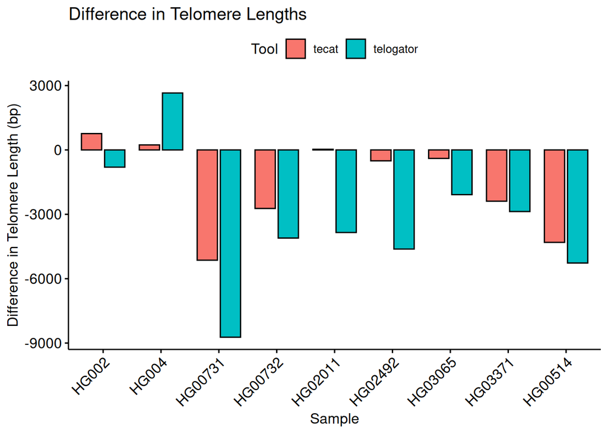

```r
diff_plot
```

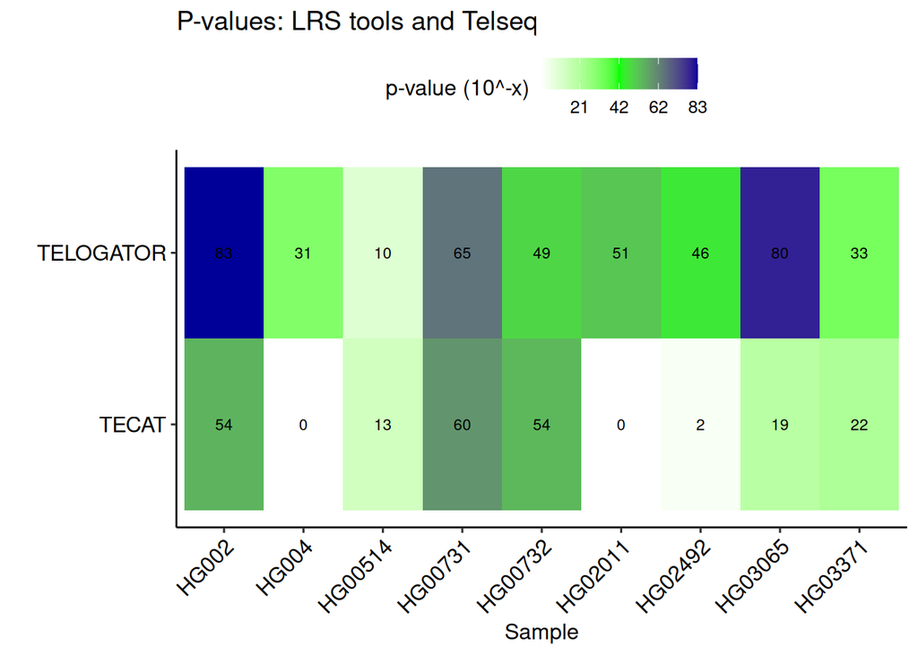

```r
pplot
```

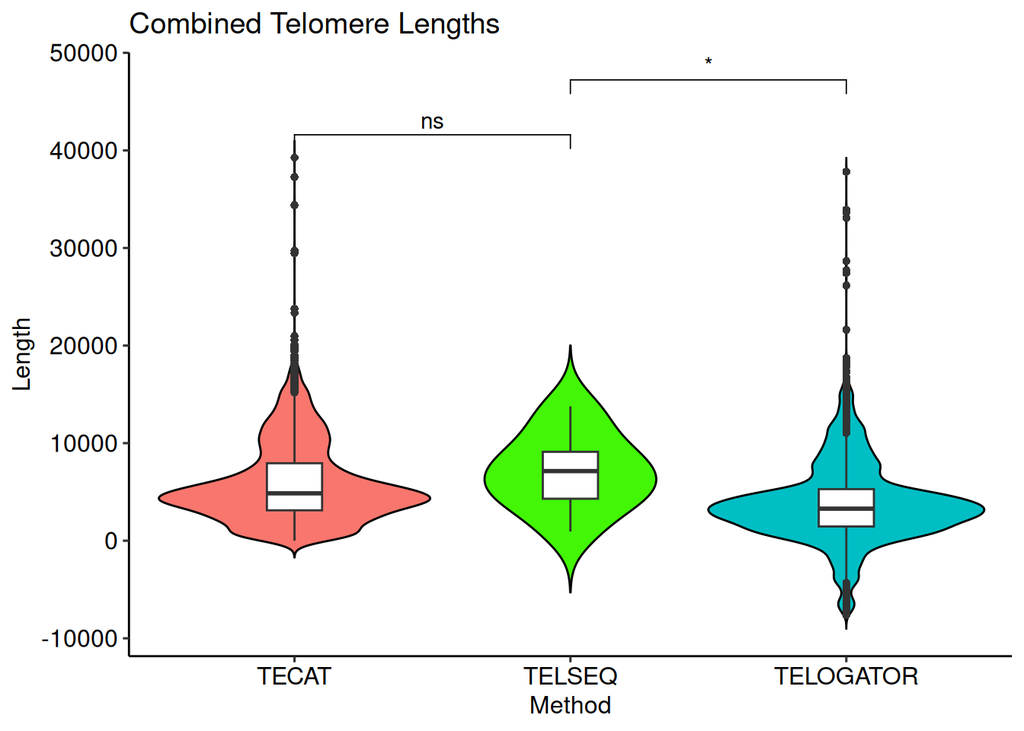

```r
violin
```

```r
grid_a <- plot_grid(
  box,                              # First plot takes full width
  plot_grid(diff_plot, pplot,            # Second row has two plots
            ncol = 2,
            labels = c("B", "C")),
  ncol = 1,                          # Stack the rows vertically
  rel_heights = c(1, 1),             # Adjust relative heights of rows
  labels = c("A", ""),
  label_size = 20               # Label only the top plot
)

#grid_a <- plot_grid(box, diff_plot, ncol = 1, nrow = 2, labels = "AUTO", label_size =20)

#grid_b <- plot_grid(pplot, violin, ncol = 1, nrow = 2, labels = "AUTO", label_size =20)

# Save plot
#ggsave(file = "./results/paper_figures/grid_a.png", plot = grid_a, width = 8, height = 8)
#ggsave(file = "./results/paper_figures/grid_b.png", plot = grid_b, width = 6, height = 8)
#ggsave(file = "./results/paper_figures/length_violin.png", plot = violin, width = 6, height = 6)

# Mean difference
diff %>%
    summarise(tecat = abs(mean(tecat)), telogator = abs(mean(telogator)))
```

```
##      tecat telogator
## 1 1603.989   3296.92
```

```r
# Sum of differences
diff %>%
    summarise(tecat = abs(sum(tecat)), telogator = abs(sum(telogator)))
```

```
##     tecat telogator
## 1 14435.9  29672.28
```

# Linear comparison of telomere lengths

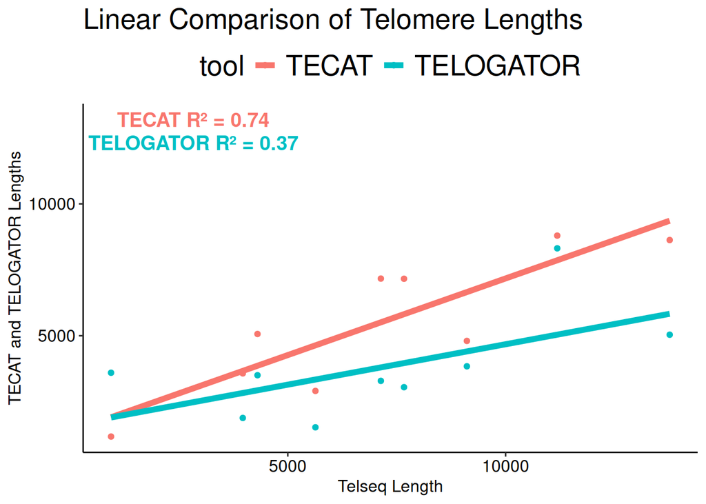

```r
telseq_line <- data.frame(
    sample = samples,
    length = unlist(telseq_length) * 1000,
    tool = rep("TELSEQ", length(unlist(telseq_length)))
)

# Order telse from least to greatest
telseq_line <- telseq_line[order(telseq_line$length), ]
telseq_samples <- telseq_line$sample

# Get means for each tool per sample
tecat_means <- sapply(tecat_lengths, mean)

# Order tecat from least to greatest
tecat_line <- data.frame(
    sample = samples,
    length = tecat_means,
    tool = rep("TECAT", length(tecat_means))
)

# Take sample order from telseq and apply it to tecat
tecat_line <- tecat_line[match(telseq_samples, tecat_line$sample), ]

# Get means for telogator tool
telogator_means <- sapply(telogator_lengths, mean)

# Order telogator from least to greatest
telogator_line <- data.frame(
    sample = samples,
    length = telogator_means,
    tool = rep("TELOGATOR", length(telogator_means))
)

# Take sample order from telseq and apply it to telogator
telogator_line <- telogator_line[match(telseq_samples, telogator_line$sample), ]

# Combine all data with tool annotations
line_data <- rbind(telseq_line, tecat_line, telogator_line)

# Convert data to long form
line_data <- data.frame(
    sample = rep(samples, 2),
    x <- rep(telseq_line$length, 2),
    y <- c(tecat_line$length, telogator_line$length),
    tool = rep(c("TECAT", "TELOGATOR"), each = length(samples))
)
colnames(line_data) <- c("sample", "x", "y", "tool")

# Perform regression for each group
fits <- line_data %>%
  group_by(tool) %>%
  do({
    mod <- lm(y ~ x, data = .)
    data.frame(r2 = summary(mod)$r.squared)
  })

# Plot with group-specific regression lines and R-squared values
lines <- ggplot(line_data, aes(x = x, y = y, color = tool)) +
  geom_point() +
  geom_smooth(method = "lm", se = FALSE, linewidth = 2) +
  annotate("text", x = min(line_data$x) * 3, y = max(line_data$y) * 1.5,
           label = paste("TECAT R² =", round(fits$r2[fits$tool == "TECAT"], 2)),
           color = "#F8766D",
           size = 5,
           fontface = "bold") +
  annotate("text", x = min(line_data$x) * 3, y = max(line_data$y) * 1.4,
           label = paste("TELOGATOR R² =", round(fits$r2[fits$tool == "TELOGATOR"], 2)),
           color = "#00BFC4",
           size = 5,
           fontface = "bold") +
  theme_pubr() +
  ggtitle("Linear Comparison of Telomere Lengths") +
  theme(plot.title = element_text(size = 20),
       legend.title = element_text(size = 20),  # Legend title font size
       legend.text = element_text(size = 20)) +
  xlab("Telseq Length") +
  ylab("TECAT and TELOGATOR Lengths") +
  scale_color_manual(values = c("#F8766D", "#00BFC4"))

lines
```

```r
# Save plot
#ggsave(file = "./results/paper_figures/lines.png", plot = lines, width = 8, height = 6)
```

# Time Benchmarks for Each LRS Tool

```r
tecat_time <- list()
telogator_time <- list()

for(s in samples) {
    tecat_time[[s]] <- as.numeric(strsplit(grep("TECAT time taken", readLines(file.path("./code/logs", paste0(s, ".log"))), value = TRUE), ":")[[1]][2])
    telogator_time[[s]] <- as.numeric(strsplit(grep("Telogator time taken", readLines(file.path("./code/logs", paste0(s, ".log"))), value = TRUE), ":")[[1]][2])
}

time_data <- data.frame()
for(s in samples) {
    time_data <- rbind(
        time_data,
        data.frame(
            time = c(tecat_time[[s]], telogator_time[[s]]),
            tool = c(rep("TECAT", 1), rep("TELOGATOR", 1)),
            sample = c(rep(s, 2))
        )
    )
}

# Convert time from seconds to minutes and label minutes
#time_data$time <- time_data$time / 60

# Summarise data again
wide <- pivot_wider(time_data, names_from = tool, values_from = time)

wide %>%
    summarise(tecat = sum(TECAT), telogator = sum(TELOGATOR))
```

```
##   tecat telogator
## 1 49764     83900
```

```r
wide %>%
    summarise(tecat = mean(TECAT), telogator = mean(TELOGATOR))
```

```
##      tecat telogator
## 1 5529.333  9322.222
```

```r
wide %>%
    summarise(tecat = sd(TECAT), telogator = sd(TELOGATOR))
```

```
##      tecat telogator
## 1 3660.135  6832.564
```

```r
# Add a size column to wide
wide$num_reads <- c(5250126, 10090702, 892957, 3326365, 869956, 731859, 1018035, 704905, 1530335)
wide$total_size_bp <- c(136833783166, 51037036142, 49544043330, 76194665538, 61543667300, 49692498960, 76207584238, 65197619090, 25992945599)

# Reorder data based on seconds taken
wide <- wide[order(wide$TECAT), ]
wide$TECAT_mbpsec <- wide$total_size_bp / wide$TECAT / 10^6
wide$TELOGATOR_mbpsec <- wide$total_size_bp / wide$TELOGATOR / 10^6
wide
```

```
## # A tibble: 9 × 7
##   sample  TECAT TELOGATOR num_reads total_size_bp TECAT_mbpsec TELOGATOR_mbpsec
##   <chr>   <dbl>     <dbl>     <dbl>         <dbl>        <dbl>            <dbl>
## 1 HG00514  1502       731   1530335   25992945599        17.3             35.6
## 2 HG004    1579      1819  10090702   51037036142        32.3             28.1
## 3 HG00732  2779      1954   3326365   76194665538        27.4             39.0
## 4 HG00731  3386     11195    892957   49544043330        14.6              4.43
## 5 HG002    4403     13206   5250126  136833783166        31.1             10.4
## 6 HG02492  7042     14877    731859   49692498960         7.06             3.34
## 7 HG02011  8329     19935    869956   61543667300         7.39             3.09
## 8 HG03065  8808      6499   1018035   76207584238         8.65            11.7
## 9 HG03371 11936     13684    704905   65197619090         5.46             4.76
```

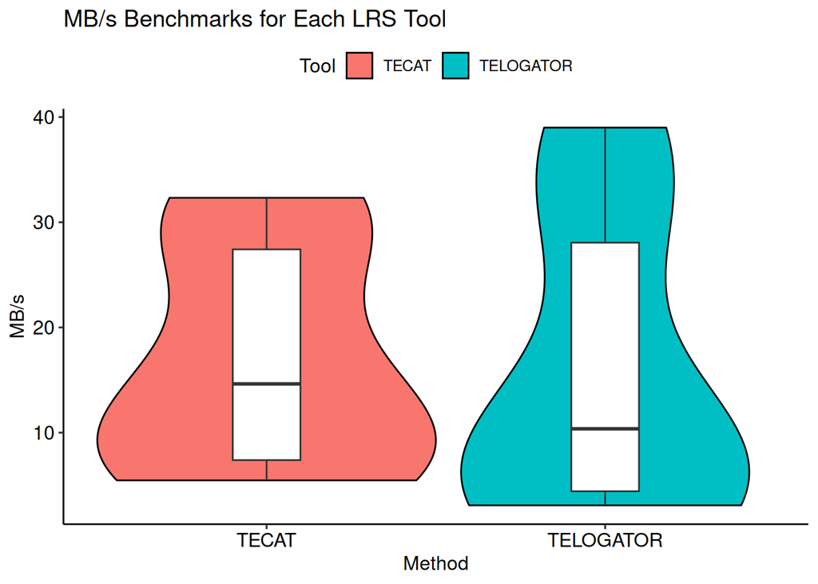

```r
long <- melt(wide, id.vars = c("sample", "num_reads", "total_size_bp"), measure.vars = c("TECAT", "TELOGATOR"))

long$mbppsec <- long$total_size_bp / long$value / 10^6

colnames(long) <- c("Sample", "Number of Reads", "Total Size (bp)", "Tool", "Time (s)", "MB per s")

# MB/s violin
time_violin <- ggviolin(long, x = "Tool", y = "MB per s", fill = "Tool",
          palette = c("#F8766D", "#00BFC4"),
          xlab = "Method",
          ylab = "MB/s",
          trim = TRUE) +
    geom_boxplot(width = 0.2, outlier.shape = 16) +
    theme_pubr() +
    ggtitle("MB/s Benchmarks for Each LRS Tool")
time_violin
```

```r
mean(long$'MB per s'[long$Tool == "TECAT"]) / mean(long$'MB per s'[long$Tool == "TELOGATOR"])
```

```
## [1] 1.078398
```

```r
mean(long$'Time (s)'[long$Tool == "TECAT"]) / mean(long$'Time (s)'[long$Tool == "TELOGATOR"])
```

```
## [1] 0.5931347
```

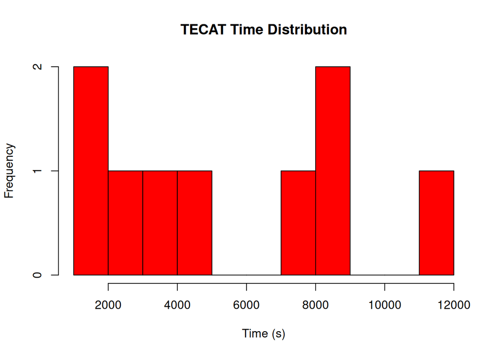

```r
# time_violin <- ggviolin(time_data, x = "tool", y = "time", fill = "tool",
#           palette = c("#F8766D", "#00BFC4"),
#           xlab = "Method",
#           ylab = "Time (minutes)",
#           trim = TRUE) +
#     geom_boxplot(width = 0.2, outlier.shape = 16) +
#     theme_pubr() +
#     ggtitle("Time Benchmarks for Each LRS Tool")

# time_violin
# Save plot
#ggsave(file = "./results/paper_figures/time_violin.png", plot = time_violin, width = 8, height = 6)

hist(wide$TECAT, breaks = 10, col = "red", xlab = "Time (s)", main = "TECAT Time Distribution")
```

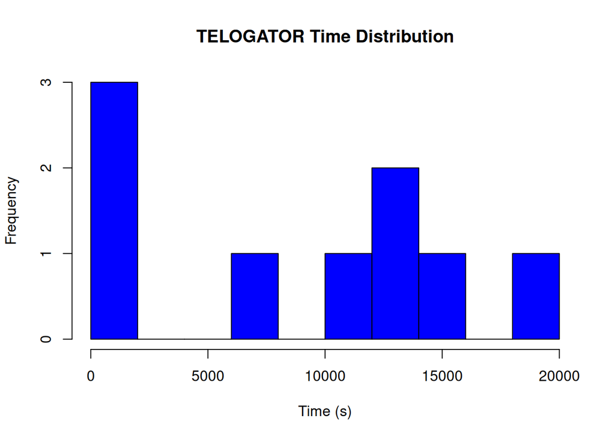

```r
hist(wide$TELOGATOR, breaks = 10, col = "blue", xlab = "Time (s)", main = "TELOGATOR Time Distribution")
```

# Estimate cost per sample

```r
# Cost per sample
consumption <- 45
cost_per_kwh <- 0.12
tecat_cost_s <- mean(long$'Time (s)'[long$Tool == "TECAT"]) * consumption / 360000 * cost_per_kwh
telogator_cost_s <- mean(long$'Time (s)'[long$Tool == "TELOGATOR"]) * consumption / 360000 * cost_per_kwh

# Cost per GB
tecat_cost_gb <- tecat_cost_s / (mean(long$'Total Size (bp)'[long$Tool == "TECAT"]) / 10^9) * 100
telogator_cost_gb <- telogator_cost_s / (mean(long$'Total Size (bp)'[long$Tool == "TELOGATOR"]) / 10^9) * 100

cost_df <- data.frame(
  Tool = c("TECAT", "TELOGATOR"),
  Cost_per_100GB = c(tecat_cost_gb, telogator_cost_gb),
  Cost_per_Sample = c(tecat_cost_s, telogator_cost_s)
)

knitr::kable(cost_df,
             format = "html",
             col.names = c("Tool", "Cost per 100GB ($)", "Cost per Sample ($)"),
             row.names = FALSE,
             align = c("c", "c", "c"),
             caption = "<font style='font-size:16pt'><b>Table 3</b> Cost Estimates</font>") %>%
  kable_classic(full_width = FALSE, html_font = "Arial", font_size = 14)
```

**Table 3** Cost Estimates

[output not shown]

# Reformat the telogator data for 5’ and 3’ arms instead of p or q arms

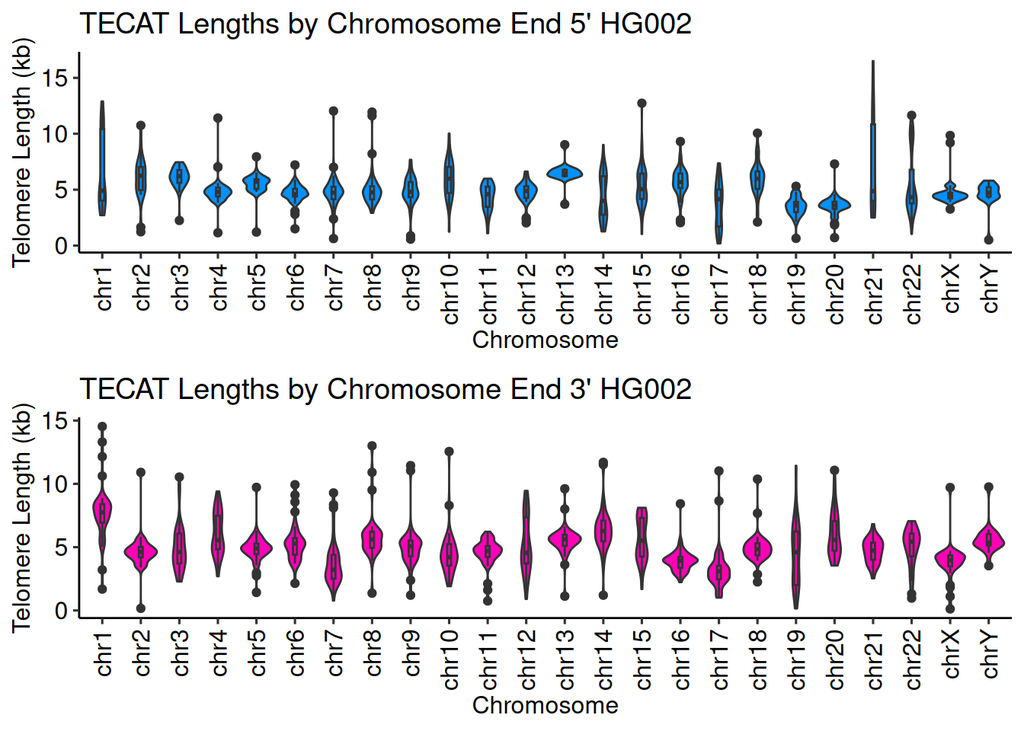

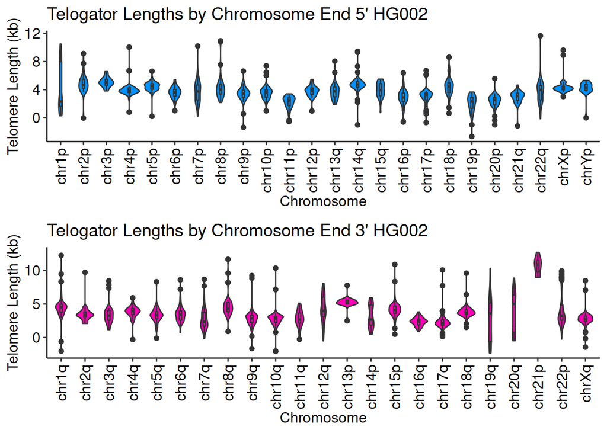

```r
dict <- data.frame(
  X.chr = c("chr1p", "chr1q", "chr2p", "chr2q", "chr3p", "chr3q", "chr4p", "chr4q",
          "chr5p", "chr5q", "chr6p", "chr6q", "chr7p", "chr7q", "chr8p", "chr8q",
          "chr9p", "chr9q", "chr10p", "chr10q", "chr11p", "chr11q", "chr12p", "chr12q",
          "chr13q", "chr13p", "chr14q", "chr14p", "chr15q", "chr15p", "chr16p", "chr16q",
          "chr17p", "chr17q", "chr18p", "chr18q", "chr19p", "chr19q", "chr20p",
          "chr20q", "chr21q", "chr21p", "chr22q", "chr22p", "chrXp", "chrXq", "chrYp",
          "chrYq"),
  prime_arm = c("5'", "3'", "5'", "3'", "5'", "3'", "5'", "3'",
                "5'", "3'", "5'", "3'", "5'", "3'", "5'", "3'",
                "5'", "3'", "5'", "3'", "5'", "3'", "5'", "3'",
                "5'", "3'", "5'", "3'", "5'", "3'", "5'", "3'",
                "5'", "3'", "5'", "3'", "5'", "3'", "5'", "3'",
                "5'", "3'", "5'", "3'", "5'", "3'", "5'", "3'")
)

# Redo previous plot and use the dictionary to convert all to 5' and 3'
samples <- c("HG002")

for (s in samples) {
  mapped_output <- tecat[[s]]
  left <- mapped_output[["results"]][mapped_output[["results"]]$chromEnd == "5'", ]
  ord <- order(as.numeric(stringr::str_extract(left$ref_name, "\\d+")))
  left <- left[ord, ]
  left$ref_name <- factor(left$ref_name, levels = unique(left$ref_name))
  right <- mapped_output[["results"]][mapped_output[["results"]]$chromEnd == "3'", ]
  ord <- order(as.numeric(stringr::str_extract(right$ref_name, "\\d+")))
  right <- right[ord, ]
  right$ref_name <- factor(right$ref_name, levels = unique(right$ref_name))
  top <- ggplot(left, aes(x = ref_name, y = telomere_length / 1000, fill = chromEnd)) +
    geom_violin(drop = FALSE) +
    geom_boxplot(width = 0.1) +
    scale_fill_manual(values = c("#0091ff")) +
    labs(x = "Chromosome",
      y = "Telomere Length (kb)",
      title = paste("TECAT Lengths by Chromosome End 5'", s)) +
      theme(text = element_text(size = 18, family = "Arial")) +
      theme_pubr() +
      theme(axis.text.x = element_text(angle=90, vjust=.5, hjust=1)) +
      theme(legend.position = "none")

  bottom <- ggplot(right, aes(x = ref_name, y = telomere_length / 1000, fill = chromEnd)) +
    geom_violin(drop = FALSE) +
    geom_boxplot(width = 0.1) +
    scale_fill_manual(values = c("#ff00b7")) +
    labs(x = "Chromosome",
      y = "Telomere Length (kb)",
      title = paste("TECAT Lengths by Chromosome End 3'", s)) +
      theme(text = element_text(size = 18, family = "Arial")) +
      theme_pubr() +
      theme(axis.text.x = element_text(angle=90, vjust=.5, hjust=1)) +
      theme(legend.position = "none")


  grid <- plot_grid(top, bottom, ncol = 1)
  tecat <- grid
  print(grid)

  # Save Plot
  #ggsave(file = file.path("./results/paper_figures/", paste0(s, "_tecat_violin.png")), plot = grid, width = 16, height = 8)

  # Do the same for Telogator
  telogator_output <- telogator[[s]]
  # Split to p and q arms by rows in the data frame
  # Turn telogator output into a long form data frame
  # Isolate just the variables we need
  telogator_output <- telogator_output[, c("X.chr", "read_TLs")]
  telogator_output <- melt(telogator_output, id.vars = "X.chr", value.name = "read_TLs")
  gator_output <- data.frame()
  for (r in 1:nrow(telogator_output)) {
    key <- telogator_output$X.chr[r]
    values <- unlist(strsplit(telogator_output$read_TLs[r], ","))
    for (v in values) {
      gator_output <- rbind(gator_output, data.frame(X.chr = key, read_TLs = as.numeric(v))
      )
    }
  }

  p <- gator_output[grepl("p", gator_output$X.chr), ]
  p[["end"]] <- "p"
  q <- gator_output[grepl("q", gator_output$X.chr), ]
  q[["end"]] <- "q"

  p <- merge(p, dict, by = "X.chr")
  q <- merge(q, dict, by = "X.chr")

  left <- rbind(p[which(p$prime_arm == "5'"), ], q[which(q$prime_arm == "5'"), ])
  ord <- order(as.numeric(stringr::str_extract(left$X.chr, "\\d+")))
  left <- left[ord, ]
  left$X.chr <- factor(left$X.chr, levels = unique(left$X.chr))
  right <- rbind(p[which(p$prime_arm == "3'"), ], q[which(q$prime_arm == "3'"), ])
  ord <- order(as.numeric(stringr::str_extract(right$X.chr, "\\d+")))
  right <- right[ord, ]
  right$X.chr <- factor(right$X.chr, levels = unique(right$X.chr))

  top <- ggplot(left, aes(x = X.chr, y = read_TLs / 1000, fill = prime_arm)) +
    geom_violin(drop = FALSE) +
    geom_boxplot(width = 0.1) +
    scale_fill_manual(values = c("#0091ff")) +
    labs(x = "Chromosome",
      y = "Telomere Length (kb)",
      title = paste("Telogator Lengths by Chromosome End 5'", s)) +
      theme(text = element_text(size = 18, family = "Arial")) +
      theme_pubr() +
      theme(axis.text.x = element_text(angle=90, vjust=.5, hjust=1)) +
      theme(legend.position = "none")

  bottom <- ggplot(right, aes(x = X.chr, y = read_TLs / 1000, fill = prime_arm)) +
    geom_violin(drop = FALSE) +
    geom_boxplot(width = 0.1) +
    scale_fill_manual(values = c("#ff00b7")) +
    labs(x = "Chromosome",
      y = "Telomere Length (kb)",
      title = paste("Telogator Lengths by Chromosome End 3'", s)) +
      theme(text = element_text(size = 18, family = "Arial")) +
      theme_pubr() +
      theme(axis.text.x = element_text(angle=90, vjust=.5, hjust=1)) +
      theme(legend.position = "none")

  grid <- plot_grid(top, bottom, ncol = 1)
  telogator <- grid
  print(grid)

  # Save Plot
  #ggsave(file = file.path("./results/paper_figures/", paste0(s, "_telogator_violin.png")), plot = grid, width = 16, height = 8)
}
```

```r
combined <- plot_grid(tecat, telogator, nrow = 2, labels = "AUTO", label_size = 20)

# Save Plot
#ggsave(file = file.path("./results/paper_figures/", "combined_violin.png"), plot = combined, width = 16, height = 16)
```